# Datos por dirección

1. **Dirección 1**: Japón → camino al circuito
2. **Dirección 2**: Japón → camino al centro
3. **Dirección 3**: Japón → camino a la rotonda
4. **Dirección 4**: Japón → camino a la playa

## Análisis del dataset completo

La distribución completa del dataset, al aplicar la técnica de clustering, permite identificar patrones claros en el tráfico vehicular. Se formaron 3 clusters principales con características distintas.

Centroides de Clusters

|  | Total_Vehiculos | Tiempo_Medio_s | Ocupacion_Espacial_% | Cantidad_muestras |
| --- | --- | --- | --- | --- |
| Cluster 0 | 0.95 | -0.28 | 0.97 | 1470.00 |
| Cluster 1 | -0.57 | -0.12 | -0.58 | 2113.00 |
| Cluster 2 | -0.93 | 3.06 | -0.91 | 218.00 |

### Análisis de los 3 grupos

**Cluster 0:**

- **Vehiculos:** 0.95 - alto
- **Tiempo medio entre autos:** - 0.28 - bajo
- **Ocupacion:** 0.97 - alto
- **Cantidad:** 1.470

Se puede observar que en este cluster el flujo vehicular es muy alto, los vehículos circulan muy cercanos entre sí debido al reducido tiempo medio entre vehículos, y la ocupación del carril es casi completa. Este cluster corresponde a tráfico pesado, donde se ocupa gran parte del carril y los vehículos avanzan de forma densa.

**Cluster 1:**

- **Vehiculos:** -0.57 - moderado/bajo
- **Tiempo medio entre autos:** -0.12 - moderado/bajo
- **Ocupacion:** -0.58 - moderado/bajo
- **Cantidad:** 2.113

En este cluster se observa un tráfico moderado, con menos vehículos que el Cluster 0. El tiempo medio entre vehículos es ligeramente bajo, lo que indica un flujo continuo pero sin saturación. La ocupación del carril es parcial, lo que permite cierto espacio entre vehículos y una circulación más fluida.

**Cluster 2:**

- **Vehiculos:** -0.93 - bajo
- **Tiempo medio entre autos:** 3.06 - alto
- **Ocupacion:** -0.91 - bajo
- **Cantidad:** 218

Este cluster representa tráfico ligero. La cantidad de vehículos es baja, el tiempo medio entre ellos es alto, y la ocupación del carril es mínima. Se corresponde a periodos de baja densidad de tráfico, donde los vehículos circulan con amplio espacio.

Distrubucion grafica de los datos

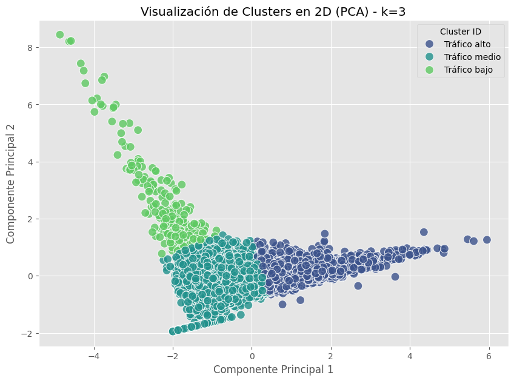

## Distribución del total del dataset por calle

Se realizara el analisis del total de cada calle, considerando los centroides obtenidos para cada cluster: **Fluido**, **Saturado** y **Vacio**.

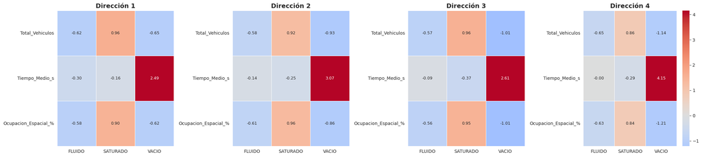

### Análisis por dirección

#### Dirección 1

- **Estado Saturado:**  
  Se observan valores alto en el total y la ocupacion, junto con tiempo entre vehiculos bajos.  
  Esto indica un alto flujo vehicular con vehículos muy próximos, esto indica tráfico denso.
- **Estado Fluido:**  
  Muestra valores negativos moderados en las tres variables, indica una circulación estable sin congestión.
- **Estado Vacío:**  
  Observamos un tiempo medio entre vehiculos alto (2.49) y valores negativos en volumen y ocupación, lo que indica periodos de baja circulación.

### Dirección 2

- **Estado Saturado:**  
  Se observa un comportamiento similar a la Dirección 1, con total y ocupacion elevados, lo que confirma escenarios de tráfico intenso.
- **Estado Fluido:**  
  Mantiene valores bajos y estables, indicando tránsito continuo sin acumulaciones.
- **Estado Vacío:**  
  Presenta un tiempo medio entre vehiculos muy alto (3.07), señal de amplios intervalos entre vehículos y mínima ocupación del carril.

### Dirección 3

- **Estado Saturado:**  
  Registra valores altos en total y ocupacion, con un tiempo medios entre vehiculos reducido (-0.37), lo que sugiere congestión frecuente.
- **Estado Fluido:**  
  Se mantiene en niveles moderados, permitiendo una circulación más ordenada.
- **Estado Vacío:**  
  Muestra menor presencia vehicular y un tiempo medios entre vehiculos elevado (2.61), correspondiente a tráfico liviano.

### Carga de los grupos y totales de los resultados

#### Carga

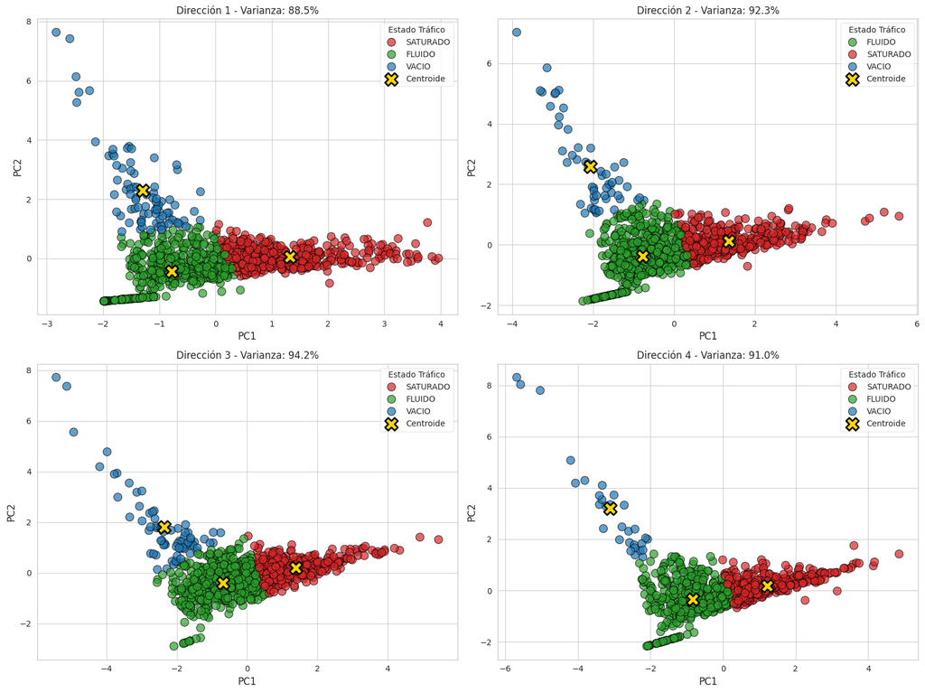

#### Totales

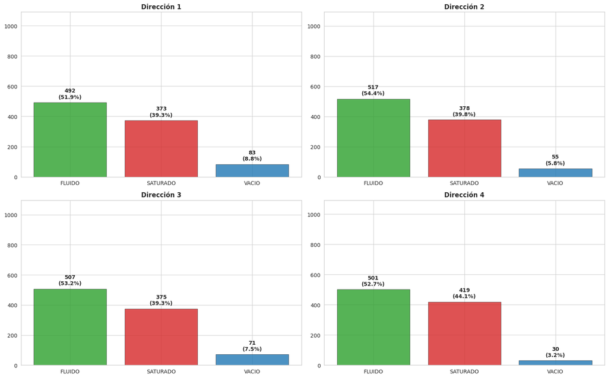

### Conclucion

| Se confirma que el comportamiento del tráfico es coherente entre calles, con diferencias minimas entre cada una

## Distribución del total del dataset por dia

Ahora se realizara el analisis por separado de cada dia, considerando los centroides obtenidos para cada cluster: **Fluido**, **Saturado** y **Vacio**.

### Analisis por dia

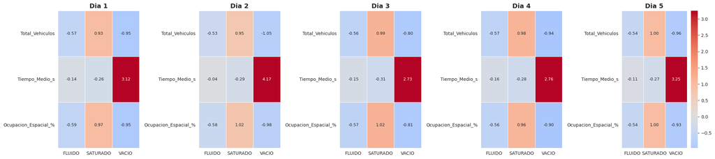

#### Días 2 al 5

Saturacian: En todos los días observados (1-5), la columna "SATURADO" presenta invariablemente valores altos en Total_Vehiculos y Ocupacion_Espacial_%. Esto confirma que el estado de congestión densa tiene la misma firma de datos a lo largo de la semana.

Fluidez: De manera similar, la columna "FLUIDO" mantiene valores negativos moderados en las tres variables medidas a través de los cinco días.

Estado Vacío: El patrón de "VACIO" es notablemente estable, caracterizado en los cinco mapas de calor por un Tiempo_Medio_s muy elevado.

### Carga de grupos y totales

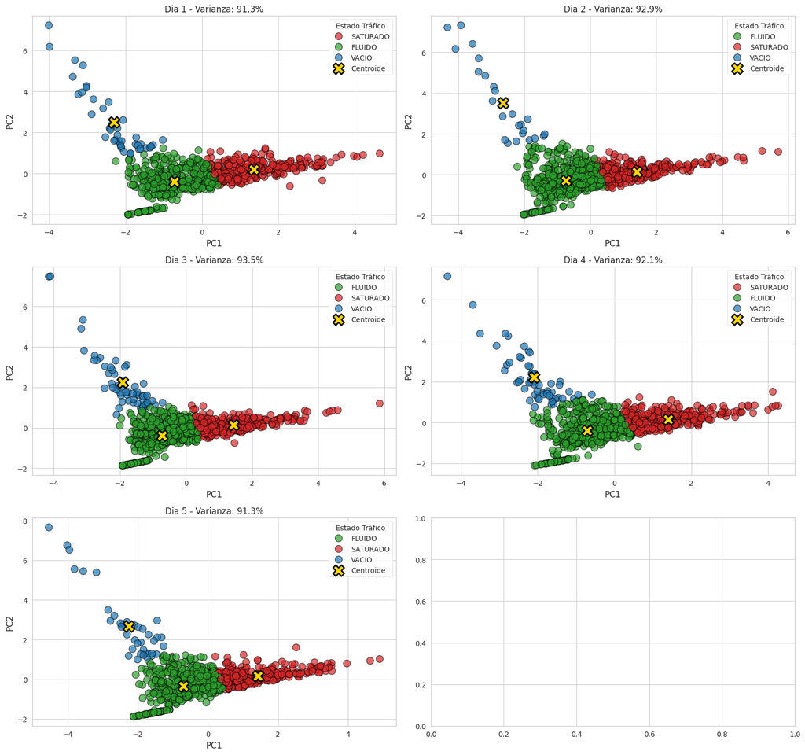

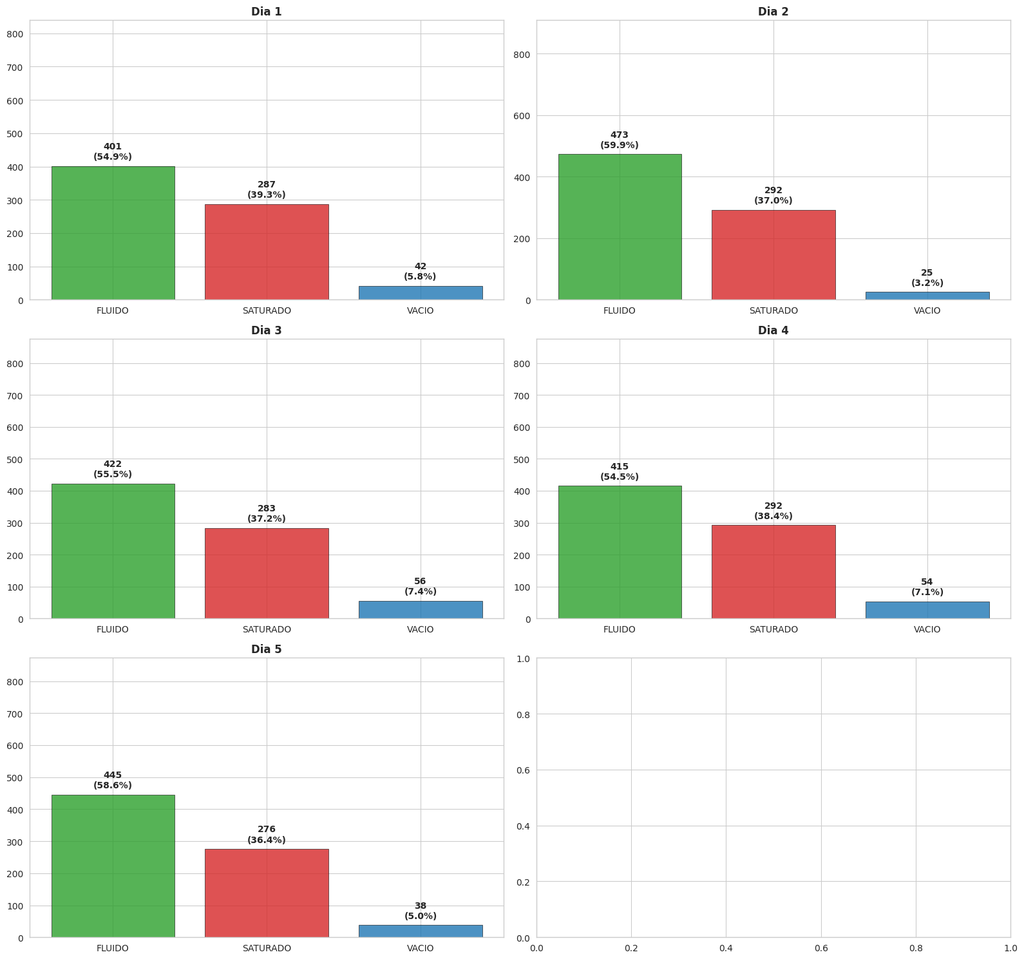